# LAB10

## symmetric outcome: `symmetric=TRUE`

## symmetric outcome: `symmetric=TRUE`

\[z_{i,j}=\beta_d^Tx_{d,i,j}+\beta_n^Tx_{i}+\beta_n^Tx_{j}+\mu+a_i+a_j+u_i^T\Lambda u_j+\epsilon_{i,j}\]

\[y_{i,j}=g(z_{i,j})\] `symmetric=TRUE`

```r
data("coldwar")
names(coldwar)
```

```
## [1] "cc"       "distance" "gdp"      "polity"
```

```r
Y=sign(apply(coldwar$cc,c(1,2),mean)) #avg across time - binary relation

Xn=cbind(apply(log(coldwar$gdp),1,mean),
         sign(apply(coldwar$polity,1,mean))
         )
Xn[,1]=Xn[,1]-mean(Xn[,1]) #centralize
dimnames(Xn)[[2]]=c("lgdp","polity")

Xd=array(dim=c(nrow(Y),nrow(Y),3))
Xd[,,1]=outer(Xn[,1],Xn[,1])
Xd[,,2]=outer(Xn[,2],Xn[,2])
Xd[,,3]=log(coldwar$distance)
dimnames(Xd)[[3]]=c("igdp","ipol","ldist")
```

```r
# fit the model
fit_amesym1=ame(Y,Xd,Xn,R=1,symmetric = TRUE,model = "ord",plot=FALSE,print = FALSE)
```

```r
summary(fit_amesym1)
```

```
##
## Regression coefficients:
##              pmean   psd z-stat p-val
## lgdp.node   -0.002 0.038 -0.053 0.958
## polity.node  0.068 0.068  1.003 0.316
## igdp.dyad   -0.026 0.021 -1.276 0.202
## ipol.dyad    0.127 0.058  2.186 0.029
## ldist.dyad   0.346 0.052  6.684 0.000
##
## Variance parameters:
##    pmean   psd
## va 0.138 0.038
## ve 1.000 0.000
```

```r
names(fit_amesym1)
```

```
## [1] "BETA"  "VC"    "APM"   "U"     "L"     "ULUPM" "EZ"    "YPM"   "GOF"
```

## `ame_rep()` for longitudinal outcome

## repeated measures data: longitudinal outcome

\[z_{i,j,t}=\beta_d^Tx_{d,i,j,t}+\beta_r^Tx_{r,i,t}+\beta_c^Tx_{c,j,t}+\mu+a_i+b_j+u_i^Tv_j+\epsilon_{i,j,t}\]

\[y_{i,j,t}=g(z_{i,j,t})\]

For \(\beta_r^Tx_{r,i,t}\) can also consider \(\beta_r^Tx_{r,i}\). For example, gender.

For \(\beta_d^Tx_{d,i,j,t}\) can consider \(y_{i,j,t-1}\) or \(y_{j,i,t-1}\) or more. (autoregression)

`ame_rep(Y,Xdyad,Xrow,Xcol)`

Add extra dimension for the time \(T\). For time-invariant covariates, need to construct array by repeating the matrix across time.

Example:

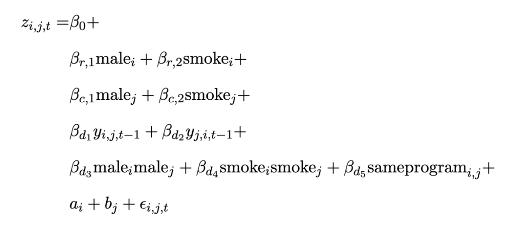

```r
data("dutchcollege")
names(dutchcollege)
```

```
## [1] "Y" "X"
```

```r
dim(dutchcollege$Y)
```

```
## [1] 32 32  7
```

```r
c(dutchcollege$Y[,,1])%>%unique() #
```

```
## [1] NA  0 -1  2  1
```

```r
Y=1*(dutchcollege$Y>=2)[,,2:7] # transfer to binary relation;
n=dim(Y)[1]
t=dim(Y)[3]

#nodal covariates
colnames(dutchcollege$X)
```

```
## [1] "male"    "smoker"  "program"
```

```r
Xnode=dutchcollege$X[,1:2]
Xnode=array(Xnode,dim=c(n,ncol(Xnode),t)) #repeat the X across time
dimnames(Xnode)[[2]]=c("male","smoker")

# dyadic covariates
Xdyad=array(dim=c(n,n,5,t))
Xdyad[,,1,]=1*(dutchcollege$Y>=2)[,,1:6] #lag Y
Xdyad[,,2,]=array(apply(Xdyad[,,1,],3,t),dim=c(n,n,t)) #transpose the matrix
Xdyad[,,3,]=outer(Xnode[,1,1],Xnode[,1,1])
Xdyad[,,4,]=outer(Xnode[,2,1],Xnode[,2,1])
Xdyad[,,5,]=outer(dutchcollege$X[,3],dutchcollege$X[,3],"==") #same program
dimnames(Xdyad)[[3]]=c("Ylag","tYlag","bothmale","bothsmoke","sameprog")
```

```r
# fit the model
fit_amet=ame_rep(Y,Xdyad,Xnode,Xnode,model = "bin",plot=FALSE,print = FALSE)
```

[output not shown]

```r
summary(fit_amet)
```

```
##
## Regression coefficients:
##                 pmean   psd z-stat p-val
## intercept      -1.612 0.170 -9.456 0.000
## male.row       -0.169 0.220 -0.771 0.441
## smoker.row     -0.458 0.182 -2.514 0.012
## male.col       -0.038 0.162 -0.237 0.813
## smoker.col     -0.237 0.145 -1.628 0.104
## Ylag.dyad       1.201 0.063 19.150 0.000
## tYlag.dyad      0.860 0.062 13.799 0.000
## bothmale.dyad   0.740 0.145  5.090 0.000
## bothsmoke.dyad  0.661 0.122  5.424 0.000
## sameprog.dyad   0.432 0.063  6.881 0.000
##
## Variance parameters:
##     pmean   psd
## va  0.223 0.073
## cab 0.033 0.034
## vb  0.119 0.038
## rho 0.641 0.038
## ve  1.000 0.000
```